[figure not shown]

# Machine Learning Programming Workshop

## 1.3 Intuition for Machine Learning (Part 2)

#### Prepared By: [Cheong Shiu Hong (FTFNCE)](https://www.linkedin.com/in/cheongshiuhong/)

## Contents

- 1) Gradients
  - 1.1 Linear Functions
  - 1.2 Non-Linear Functions
  - 1.3 Special Functions
  - 1.4 Convex Functions
  - 1.5 Chain Rule in Differentiation
- Practice Questions
- 2) Gradients in Action
  - 2.1 Cost Function
  - 2.2 Gradient Descent

```python
import numpy as np
import matplotlib.pyplot as plt
```

# Calculus

### What is Calculus?

#### Calculus is all about the rate of change.

#### For us, we will focus on differentiation to find the gradients of a fuction with respective to it's individual parameters. (Multivariate Calculus)

# 1) Gradients

return to top

### Think of the Rate of Change as the Gradient of a Line (Function)

## 1.1 Linear Functions

return to top

### Where the Gradient is Rise over Run ($\frac{\triangle Y}{\triangle X}$)

[figure not shown]

### $y = 2x + 3$

### $\frac{dy}{dx} = 2$

## 1.2 Non-Linear Functions

return to top

### What if the Line is not Linear?

[figure not shown]

### Use Differentiation to Find the Gradient at Point X

### $y = x^2 + 20$

### $\frac{dy}{dx} = 2x$

```python
def func(x):
    return x**2 + 20

def gradient_at(x):
    return 2*x
```

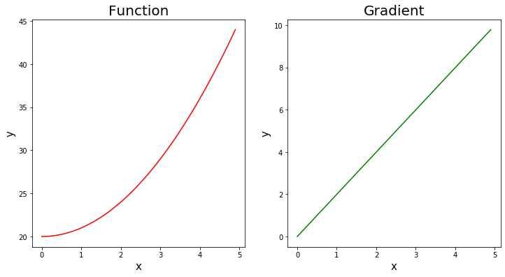

```python
x = np.array(list(range(50)))/10

fig = plt.figure(figsize=(12,6))
fig.add_subplot(111)


plt.subplot(1,2,1)
plt.title('Function', fontsize=20); plt.xlabel('x', fontsize=15); plt.ylabel('y', fontsize=15)
plt.plot(x, func(x), label='Function', c='r')
plt.subplot(1,2,2)
plt.title('Gradient', fontsize=20); plt.xlabel('x', fontsize=15); plt.ylabel('y', fontsize=15)
plt.plot(x, gradient_at(x), label='Gradient', c='g')
plt.show();
```

```python
gradient_at(4)
```

```
8
```

## 1.3 Special Functions

return to top

#### Exponential Functions

### $y = e^{2x}$

### $\frac{dy}{dx} = 2e^{2x}$

```python
def func(x):
    return np.exp(2*x)

def gradient_at(x):
    return 2 * np.exp(2*x)
```

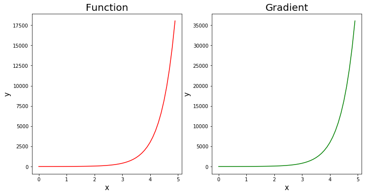

```python
x = np.array(list(range(50)))/10

fig = plt.figure(figsize=(12,6))
fig.add_subplot(111)

plt.subplot(1,2,1); plt.title('Function', fontsize=20); plt.xlabel('x', fontsize=15); plt.ylabel('y', fontsize=15)
plt.plot(x, func(x), label='Function', c='r')

plt.subplot(1,2,2); plt.title('Gradient', fontsize=20); plt.xlabel('x', fontsize=15); plt.ylabel('y', fontsize=15)
plt.plot(x, gradient_at(x),  label='Gradient', c='g')

plt.show();
```

#### Logarithmic Functions

### $y = ln(5x)$

### $\frac{dy}{dx} = \frac{1}{x}$

```python
def func(x):
    return np.log(5*x)

def gradient_at(x):
    return 1/x
```

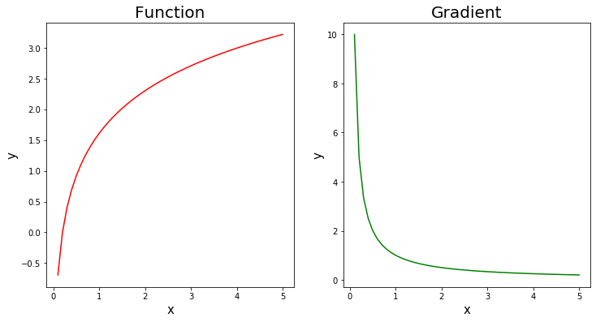

```python
x = np.array(list(range(50)))/10 + 0.1

fig = plt.figure(figsize=(12,6))
fig.add_subplot(111)

plt.subplot(1,2,1)
plt.title('Function', fontsize=20); plt.xlabel('x', fontsize=15); plt.ylabel('y', fontsize=15)
plt.plot(x, func(x), label='Function', c='r')
plt.subplot(1,2,2)
plt.title('Gradient', fontsize=20); plt.xlabel('x', fontsize=15); plt.ylabel('y', fontsize=15)
plt.plot(x, gradient_at(x),  label='Gradient', c='g')
plt.show();
```

## 1.4 Gradients of Convex Functions

return to top

### $y = x^2 - 9x + 25$

### $\frac{dy}{dx} = 2x - 9$

```python
def func(x):
    return x**2 - 9*x + 25

def gradient_at(x):
    return 2*x - 9
```

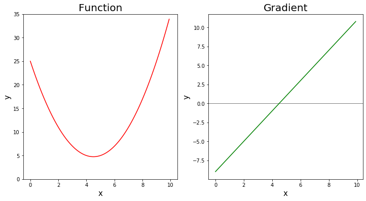

```python
x = np.array(list(range(100)))/10

fig = plt.figure(figsize=(12,6))
fig.add_subplot(111)

plt.subplot(1,2,1); plt.axis([-0.5, 10.5, 0, 35])
plt.title('Function', fontsize=20); plt.xlabel('x', fontsize=15); plt.ylabel('y', fontsize=15)
plt.plot(x, func(x), label='Function', c='r')
plt.subplot(1,2,2)
plt.title('Gradient', fontsize=20); plt.xlabel('x', fontsize=15); plt.ylabel('y', fontsize=15)
plt.axhline(0, c='black', linewidth=0.5)
plt.plot(x, gradient_at(x),  label='Gradient', c='g')
plt.show();
```

```python
gradient_at(5)
```

```
1
```

### $\because 2x - 9 = Gradient$,

### $x = \frac{Gradient + 9}{2}$

```python
def find_x(gradient):
    return (gradient + 9)/2
```

### At Minimum Point: $\frac{dy}{dx} = 0$

```python
find_x(0)
```

```
4.5
```

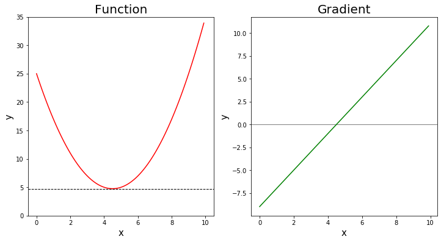

```python
x = np.array(list(range(100)))/10

fig = plt.figure(figsize=(12,6))
fig.add_subplot(111)

plt.subplot(1,2,1); plt.axis([-0.5, 10.5, 0, 35])
plt.title('Function', fontsize=20); plt.xlabel('x', fontsize=15); plt.ylabel('y', fontsize=15)
plt.plot(x, func(x), label='Function', c='r')
plt.axhline(func(find_x(0)), c='black', linestyle='--', linewidth=1)
plt.subplot(1,2,2)
plt.title('Gradient', fontsize=20); plt.xlabel('x', fontsize=15); plt.ylabel('y', fontsize=15)
plt.axhline(0, c='black', linewidth=0.5)
plt.plot(x, gradient_at(x),  label='Gradient', c='g')
plt.show();
```

```python
# Minimum Point:
func(find_x(0))
```

```
4.75
```

## 1.5 Chain Rule in Differentiation

return to top

### $y = 2x + 10$

### $z = y - 3$

### $a = z^2$

### Therefore:

### $a = (y-3)^2$

### $a = ((2x + 10) - 3)^2$

## What is $\frac{da}{dx}$?

## $\frac{da}{dx} = \frac{da}{dz} \times \frac{dz}{dy} \times \frac{dy}{dx}$

## $\frac{da}{dz} = 2z$

## $\frac{dz}{dy} = 1$

## $\frac{dy}{dx} = 2$

### Therefore:

## $\frac{da}{dx} = 2z \times 1 \times 2$

## $\frac{da}{dx} = 4z = 4(y-3) = 4((2x + 10) - 3) = 4(2x + 7) = 8x + 28$

### Key Point: We can solve for the Gradients of Nested Functions by Multiplying the Gradients Together

# Practice Questions:

return to top

### Question 1

### $f(x) = 2x^2 + 4x$

#### Differentiate the Above Function with Respect to X

### Question 2

### $f(x, y) = 2x^2y + 4xy^3$

#### a) Differentiate the Above Function with Respect to X

#### b) Differentiate the Above Function with Respect to Y

### Question 3

### $y = 5x^2 + 2x$ $z = 2y^2 - 5$

#### Differentiate Z with Respect to X

### Question 4

### $y = x^2 - 9x + 25$

#### What is the Minimum Value of the Above Convex Function? (Find X and Y at the Minimum Point)

# 2) Gradients in Action

return to top

### So why are Gradients so important in Machine Learning?

## 2.1 Cost Function

return to top

### Recall our Problem from Earlier:

#### When trying to find the best estimate, we want to minimize the Error.

#### The Term "Cost Function" is used to represent the Total Error (Summation) for Each Datapoint.

#### We will see later on that, Cost Functions in most cases are Convex Functions

Which is to say, we can find the point of Minimum Error with Differentiation, by finding the point where the Gradients of the Cost Function with respect to each of the Parameters $\approx$ 0.

And to Differentiate the Error Function with respect to each Parameter, will require the application of the **Chain Rule**.

### Consider "Mean Squared Error" as our Cost Function of a Linear Regression Model as a Nested Function:

## $MSE = \frac{1}{m}\sum\limits^{m}_{i=1} (\hat{y} - y)^2$

## $\hat{y} = w.x + b$

#### Where [w] and [b] are the Parameters to be Optimized

## $\therefore \frac{dMSE}{dw} = \frac{dMSE}{d\hat{y}} \times \frac{d\hat{y}}{dw}$

## $\therefore \frac{dMSE}{db} = \frac{dMSE}{d\hat{y}} \times \frac{d\hat{y}}{db}$

#### **The Chain can be Longer in More Complex Models

### Goal: Find the Optimal Combination of [w] and [b] to achieve the Minimum Possible MSE

### Therefore, we want both $\frac{dMSE}{dw}$ and $\frac{dMSE}{db}$ to $\approx$ 0

## 2.2 Gradient Descent

return to top

### The Jacobian Matrix

The Jacobian Matrix is just a term for the Matrix of Gradients.

## Jacobian Matrix $= \left[ {\begin{array}{c} \frac{dMSE}{dw} \\ \frac{dMSE}{db} \end{array} } \right] $

### Plotting Our Cost Function against one of the Parameter

[figure not shown]

#### When the Parameter is too low, the Cost of our Model Increases. When the Parameter is too high, the Cost of our Model Increases as well.

### At Optimal Point of the Parameter, the Cost of our Model at Minimum

#### i.e. the Gradient is 0

#### **Take note that the Cost Curve is a Convex Function

### How then, should we choose the weights for the Model?

Since we are doing **Machine Learning**, we can **Randomly Initialize** the weights and let the Machine **Learn** the Optimal Values of each Parameter.

We can adjust our randomly initialized Parameters towards the Optimal Point by utilizing the Jacobian Matrix (Gradients of Cost Curve with respect to each Parameter)

[figure not shown]

### Scenerio 1 - Parameter too Large:

- Gradient is **POSITIVE**
- Want to **DECREASE** the Value of the Parameter

Since we want to **Decrease** the value of the parameter, we can **subtract** a **Positive** Number from the Parameter.

Guess what Number is **Positive**??

### Scenerio 2 - Parameter too Small:

- Gradient is **NEGATIVE**
- Want to **INCREASE** the Value of the Parameter

Since we want to **Increase** the value of the parameter, we can **subtract** a **Negative** Number from the Parameter.

Note: Subtracting a Negative Number is the same as Adding a Positive Number

Guess what Number is **Negative**??

### Intuition:

If the **Gradient** is **Positive**, it means that the Parameter is too **Large**, and we can **Reduce** it by **Subtracting** the **Positive Gradient**.

If the **Gradient** is **Negative**, it means that the Parameter is too **Small**, and we can **Increase** it by **Subtracting** the **Negative Gradient**.

#### Therefore, Gradient Descent is Pretty Much:

### $w := w - \frac{dMSE}{dw}$

### $b := b - \frac{dMSE}{db}$

#### or

#### For Any Parameter:

### $Param := Param - \frac{dMSE}{dParam}$

**However**, Gradients can be **HUGE** and it can throw the Parameters **WAY OFF**

#### Therefore, we scale the Gradient Down by a Small Number (Alpha)

A.K.A the **Learning Rate**, which is a Hyperparameter for the Training Algorithm

### $w := w - \alpha\frac{dMSE}{dw}$

### $b := b - \alpha\frac{dMSE}{db}$

#### or

#### For Any Parameter:

### $Param := Param - \alpha\frac{dMSE}{dParam}$

### With this, we are now ready to look at our First Example: Linear Regression

Previous: Next:

Intuition for Machine Learning (Part 1) Linear Regression